# Application of the statistical model on the subtrees

# Introduction

In this document, we present how to use the proposed approach on a fake dataset. Below we use the output subtrees from the `GenomicSequences_to_TransmissionChains.Rmd` script. We also use similar code than in `fit_model.Rmd` script but with slight variations:

1. The sampling proportion is estimated from epidemiological data, and then the hyperparameter values are fixed according to this prior information.
2. We slightly change the posterior sampler to take a bootstraped collection of phylogenetic subtrees into account.

The final output are the posterior sample and an estimate of the proportion of introductions.

### Outline

# Preprocess

In this Section, we give details about important preprocess steps that are different from the preprocesses that we describe in the `fit_model.Rmd` script.

### Estimate the prior sampling proportion

In this Section, we describe how to estimate the sampling proportion from epidemiological data. The idea is to compute the proportion of sequenced persons among the diagnosed persons. Notice that:

1. By computing this proportion, we only approximate the ‘true’ sampling proportion which is the proprotion of sequenced persons in the infected population.
2. In this document, we focus on the overall sampling proportion. Nevertheless, using a slight variation of this script, we can obtain the sampling proportion of a specific population.

**Estimation of the overall sampling proportion :**

```r
person <- readRDS(paste(path_RDS,"person_modified.rds",sep=""))
sequences_meta <- readRDS(paste(path_RDS,"sequences_meta_modified.rds",sep=""))

diagnosed_n_sequenced <- person$newnum %in% sequences_meta$newnum
p0 <- as.numeric( prop.table(table(diagnosed_n_sequenced))["TRUE"] )
```

**Estimation of the sampling proportion for a specific subgroup:**

```r
trait <- person$main_transm2 == "IDU"

diagnosed_n_sequenced <- person$newnum[trait] %in% sequences_meta$newnum
p0_IDU <- as.numeric( prop.table(table(diagnosed_n_sequenced))["TRUE"] )
```

### Load the data

Below, we show how to load the subtree sizes and to set up a `data` object for the following functions.

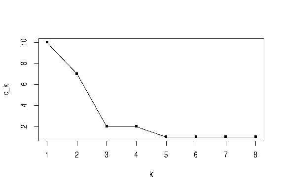

```r
load(paste(path_clade,"Clades_save.RData",sep=""))
c <- rev(sort( unlist( lapply(clades,function(clade) length(clade$tip.label)) ) ))
data <- list(
 c = as.numeric(c),
 N = sum(c),
 K = length(c)
)

plot(data$c,type="o",pch=15,cex=0.7,xlab="k",ylab="c_k")
```

Notice that for this example, there is a bunch of very small subtrees that is the consequence of adding a high rate of mutations in the viral RNA sequences. In pratice, we expect to get at least some big subtrees.

If we want to fit bootstrap subtrees, we need to define `data` in a different way, see below.

```r
datas <- list() ; length(datas) <- bs.n+1

datas[[1]] <- data
for(b in 1:bs.n){
load(paste(path_clade,"Clades_save_",sprintf("%03d",b-1),".RData",sep=""))
c <- rev(sort( unlist( lapply(clades,function(clade) length(clade$tip.label)) ) ))
data_tmp <- list(
 c = as.numeric(c),
 N = sum(c),
 K = length(c)
)
data_tmp$c <- data_tmp$c[data_tmp$c != 0]
datas[[b+1]] <- data_tmp
}
```

### Define options and hyperparameters

In this Section, we deal with hyperparameter values and the options for the sampler algorithm. Below, we describe how to derive hyperparameter values from the prior overall sampling proportion, `p0`, and the ML estimate of alpha, `alpha0`.

```r
r0 <- data$N*(1-p0)/p0
K0 <- data$K / p0
alpha_estimate <- alpha_estimator(data$c,c(0.1,data$N),nbre_alpha=1e4)
alpha0 <- alpha_estimate$alpha_hat

hyperparam <- list(
 lambda1  = alpha0^2,
 lambda2  = alpha0,
 eta1 = data$N+1,
 eta2 = data$N*(1-p0)/p0+1,
 pi    = 1-p0,
 kappa = data$N
)
```

The options for the sammpler algorithm are:

- `n_iter`: the size of the output sample
- `burnin`: the number of iteration for the burnin periode (optional)
- `lambda`: related to the number of swap moves at each iteration of the Parallel Tempering algorithm (optional)
- `thin`: to set in order to keep only one iteration every `thin` iterations (optional)
- `temperatures`: the temperatures for the different chains of the Parallel Tempering algorithm.
- `target`: a character chain to determine the target distribution, the prior or the posterior (optional).

```r
param <- list(n_iter = 1e3,
              burnin=1e2,
              lambda=5,
              thin=5,
              temperatures = rev(seq(0,1,le=5+1)[-1]))
param_prior <- param
param_prior$target <- "prior"
```

# Application

In this Section, we present how to get a prior sample by using a Metropolis Hastings (MH) algorithm, or a posterior sample by using a Parallel Tempering (PT) algorithm.

**Prior sample:** The prior distribution is quite simple to sample, then using a MH is acceptable. There are two provided functions for running this algorithm: `MH` in `R` or `MH_cpp` in `Rcpp`.

```r
prior_sample <- MH(param_prior,data,hyperparam)
```

```
#> MH:
#>  0%
#>  10%
#>  20%
#>  30%
#>  40%
#>  50%
#>  60%
#>  70%
#>  80%
#>  90%
#>  100%
```

```r
prior_sample_cpp <- MH_cpp(param_prior,data,hyperparam,TRUE)
```

**Posterior sample:**

```r
posterior_sample <- PT(param,data,hyperparam)
```

```
#> PT:
#>  Burnin.
#>  0%
#>  10%
#>  20%
#>  30%
#>  40%
#>  50%
#>  60%
#>  70%
#>  80%
#>  90%
#>  100%
```

```r
posterior_sample_cpp <- PT_cpp(param,data,hyperparam,TRUE)
```

```
#> Burnin done.
```

```
#> The Rcpp code is  10.68784 times faster.
```

**Posterior sample with bootstrap input data:**

```r
posterior_sample_bs <- PT_bs(param,datas,hyperparam)
```

```
#> PT:
#>  0%
#>  10%
#>  20%
#>  30%
#>  40%
#>  50%
#>  60%
#>  70%
#>  80%
#>  90%
#>  100%
#> PT:
#>  0%
#>  10%
#>  20%
#>  30%
#>  40%
#>  50%
#>  60%
#>  70%
#>  80%
#>  90%
#>  100%
#> PT:
#>  0%
#>  10%
#>  20%
#>  30%
#>  40%
#>  50%
#>  60%
#>  70%
#>  80%
#>  90%
#>  100%
```

```r
posterior_sample_bs_cpp <- PT_bs_cpp(param,datas,hyperparam,TRUE)
```

```
#> The Rcpp code is  2.03744 times faster.
```

# Diagnostics

In this Section, we show how to obtain the outputs (trace and model parameter estimates) and how to compute some diagnostics to assess the convergence of the sampler algorithm.

### For one dataset

**Trace plots:**

For each parameter, we have a MCMC sample for all the target tempered distributions of the Parallel Tempering algorithm. As an example, we first show the trace of a model parameter (`alpha`):

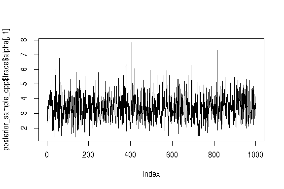

```r
plot(posterior_sample_cpp$trace$alpha[,1],type="l")
```

Noticed that the numerical results are not so good since we choose a small number of iterations and a small number for the thinning. For a real data study, it should be expected to fix these values so that the mixing proporties of the chain are acceptable.

Below, we show for `alpha` the difference between the tempered chains.

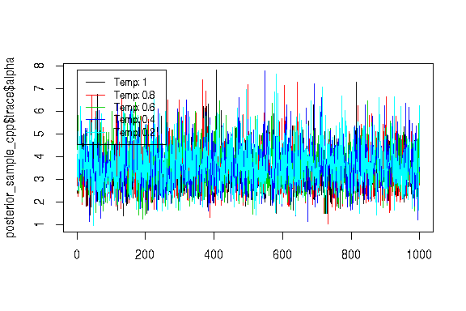

```r
matplot(posterior_sample_cpp$trace$alpha,type="l",lty=1)
legend(0, max(posterior_sample_cpp$trace$alpha), legend=paste("Temp:", param$temperatures),
       col=1:length(param$temperatures), lty=1, cex=0.8)
```

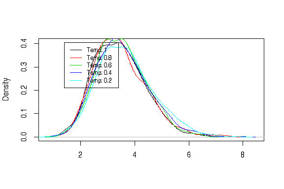

```r
plot(density(posterior_sample_cpp$trace$alpha[,1]),main="",xlab="")
for(i in 2:length(param$temperatures))
 lines(density(posterior_sample_cpp$trace$alpha[,i]),col=i)
legend(min(posterior_sample_cpp$trace$alpha[,1]),
       max(density(posterior_sample_cpp$trace$alpha[,1])$y), legend=paste("Temp:", param$temperatures),
       col=1:length(param$temperatures), lty=1, cex=0.8)
```

**Geweke test:**

```r
threshold <- 0.01
```

```r
mcmc_alpha <- as.mcmc(posterior_sample_cpp$trace$alpha[,1])

geweke_z_alpha    <- geweke.diag(mcmc_alpha)
geweke_z_alpha    <- 1-pnorm(abs(geweke_z_alpha$z),0,1)
```

```
#> The p-value of the Geweke test is : 0.4152818 . Then the null hypothesis is not rejected: the means of the first part and the last part of the Markov chain are not significatively different, which could be an evidence in support of the convergence of the chain.
```

**Heidelberg test:**

```r
heildel_sta_alpha <- heidel.diag(mcmc_alpha)[3]
```

```
#> The p-value of the Heidelberger and Welch's test is : 0.6702414 . Then the null hypothesis is not rejected: the sample values come from a stationary distribution.
```

### For several bootstrap datasets

Below, we show the same plots as above but with the boostratp input data.

**Trace plots:**

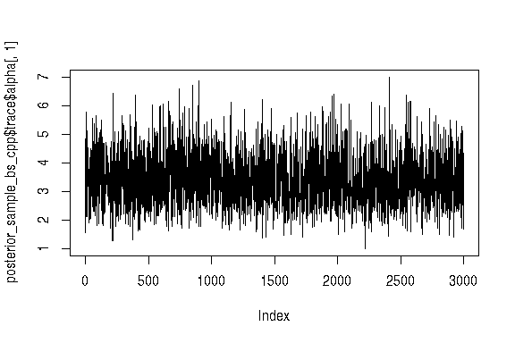

```r
plot(posterior_sample_bs_cpp$trace$alpha[,1],type="l")
```

Below, we show for `alpha` the difference between the tempered chains.

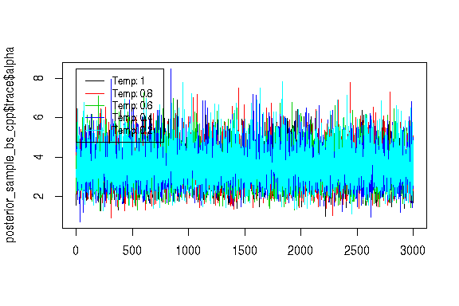

```r
matplot(posterior_sample_bs_cpp$trace$alpha,type="l",lty=1)
legend(0, max(posterior_sample_bs_cpp$trace$alpha), legend=paste("Temp:", param$temperatures),
       col=1:length(param$temperatures), lty=1, cex=0.8)
```

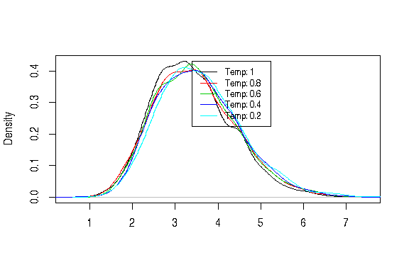

```r
plot(density(posterior_sample_bs_cpp$trace$alpha[,1]),main="",xlab="")
for(i in 2:length(param$temperatures))
 lines(density(posterior_sample_bs_cpp$trace$alpha[,i]),col=i)
legend(mean(posterior_sample_bs_cpp$trace$alpha[,1]),
       max(density(posterior_sample_bs_cpp$trace$alpha[,1])$y), legend=paste("Temp:", param$temperatures),
       col=1:length(param$temperatures), lty=1, cex=0.8)
```

**Geweke test:**

```r
threshold <- 0.01
```

```r
mcmc_alpha <- as.mcmc(posterior_sample_bs_cpp$trace$alpha[,1])

geweke_z_alpha    <- geweke.diag(mcmc_alpha)
geweke_z_alpha    <- 1-pnorm(abs(geweke_z_alpha$z),0,1)
```

```
#> The p-value of the Geweke test is : 0.006436291 . Then the null hypothesis is rejected: the means of the first part and the last part of the Markov chain are significatively different, which could be an evidence in support of the divergence of the chain.
```

**Heidelberg test:**

```r
heildel_sta_alpha <- heidel.diag(mcmc_alpha)[3]
```

```
#> The p-value of the Heidelberger and Welch's test is : 0.7472 . Then the null hypothesis is not rejected: the sample values come from a stationary distribution.
```

# Results

In this Section, we give the estimate of proportion of introductions from the posterior sample.

### For one dataset

We first compute the posterior distribution of the proportion of introductions.

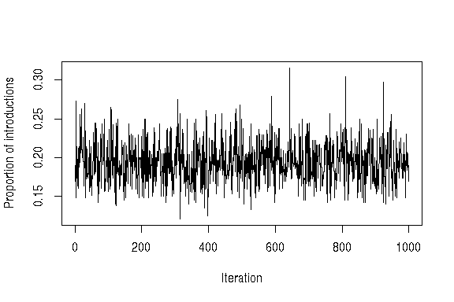

Second, the estimate is:

```r
PI_estimate <- mean(PIs[-(1:param$burnin)])
CI_PI <- quantile(PIs,c(0.025,0.975))

cat("Estimate: ", round(PI_estimate,3), " (",round(CI_PI[1],3),"-",
    round(CI_PI[2],3),")",sep="")
```

```
#> Estimate: 0.194 (0.145-0.25)
```

### For several bootstrap datasets

We first compute the posterior distribution of the proportion of introductions.

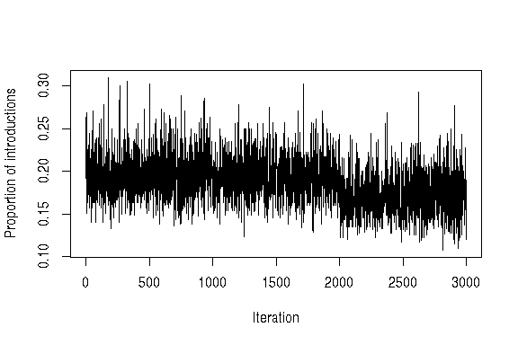

Second, the estimate is:

```r
PI_estimate <- mean(PIs[-(1:param$burnin)])
CI_PI <- quantile(PIs,c(0.025,0.975))

cat("Estimate: ", round(PI_estimate,3), " (",round(CI_PI[1],3),"-",
    round(CI_PI[2],3),")",sep="")
```

```
#> Estimate: 0.186 (0.135-0.244)
```